# Data Wrangling Techniques Applied to Biological Data

## Getting to Know the Data

The Metabric study characterized the genomic mutations and gene expression profiles for 2509 primary breast tumours. In addition to the gene expression data generated using microarrays, genome-wide copy number profiles were obtained using SNP microarrays. Targeted sequencing was performed for 2509 primary breast tumours, along with 548 matched normals, using a panel of 173 of the most frequently mutated breast cancer genes as part of the Metabric study.

**Refrences:**

- [Curtis *et al.*, Nature 486:346-52, 2012](https://pubmed.ncbi.nlm.nih.gov/22522925)
- [Pereira *et al.*, Nature Communications 7:11479, 2016](https://www.ncbi.nlm.nih.gov/pubmed/27161491)

Both the clinical data and the gene expression values were downloaded from [cBioPortal](https://www.cbioportal.org/study/summary?id=brca_metabric).

## Download the Data

Follow [this link](https://cbioportal-datahub.s3.amazonaws.com/brca_metabric.tar.gz) to download the metabric dataset and copy the downloaded folder into the data folder in your working directory.

[figure not shown]

## Overview of the Data

The following table illustartes the column names and descriptions of the metabric data frame we will be using in this case study.

Description of column names in the metabric dataset

| Column Name | Description |
| --- | --- |
| Patient_Id | #Identifier to uniquely specify a patient. |
| Lymph_Nodes_Examined_Positive | Number of lymphnodes positive |
| Npi | Nottingham prognostic index |
| Cellularity | Tumor Content |
| Chemotherapy | Chemotherapy. |
| Cohort | Cohort |
| Er_Ihc | ER status measured by IHC |
| Her2_Snp6 | HER2 status measured by SNP6 |
| Intclust | Integrative Cluster |
| Age_At_Diagnosis | Age at Diagnosis |
| Os_Months | Overall survival in months since initial diagonosis. |
| Os_Status | Overall patient survival status. |
| Threegene | 3-Gene classifier subtype |
| Vital_Status | The survival state of the person. |
| Radio_Therapy | Radio Therapy |
| Cancer_Type | Cancer Type |
| Cancer_Type_Detailed | Cancer Type Detailed |
| Er_Status | ER Status |
| Her2_Status | HER2 Status |
| Grade | Numeric value to express the degree of abnormality of cancer cells, a measure of differentiation and aggressiveness. |
| Oncotree_Code | Oncotree Code |
| Pr_Status | PR Status |
| Sample_Type | The type of sample (i.e., normal, primary, met, recurrence). |
| Tumor_Size | Tumor size. |
| Tumor_Stage | Tumor stage. |
| Tmb_Nonsynonymous | TMB (nonsynonymous) |
| FOXA1 | FOXA1 Expression data |
| MLPH | MLPH Expression data |
| ESR1 | ESR1 Expression data |
| ERBB2 | ERBB2 Expression data |
| TP53 | TP53 Expression data |
| PIK3CA | PIK3CA Expression data |
| GATA3 | GATA3 Expression data |
| PGR | PGR Expression data |

## Pre-Processing the Data

### Task 1: Patient and sample data

**1. Import the clinical patient data file into a data frame named patient_info. If the import is successful, the expected output for the `patient_info` command would be as follows.**

| PATIENT_ID | LYMPH_NODES_EXAMINED_POSITIVE | NPI | CELLULARITY | CHEMOTHERAPY | COHORT | ER_IHC | HER2_SNP6 | HORMONE_THERAPY | INFERRED_MENOPAUSAL_STATE | SEX | INTCLUST | AGE_AT_DIAGNOSIS | OS_MONTHS | OS_STATUS | CLAUDIN_SUBTYPE | THREEGENE | VITAL_STATUS | LATERALITY | RADIO_THERAPY | HISTOLOGICAL_SUBTYPE | BREAST_SURGERY | RFS_MONTHS | RFS_STATUS |
| --- | --- | --- | --- | --- | --- | --- | --- | --- | --- | --- | --- | --- | --- | --- | --- | --- | --- | --- | --- | --- | --- | --- | --- |
| MB-0000 | 10 | 6.044 | NA | NO | 1 | Positve | NEUTRAL | YES | Post | Female | 4ER+ | 75.65 | 140.50000 | 0:LIVING | claudin-low | ER-/HER2- | Living | Right | YES | Ductal/NST | MASTECTOMY | 140.50000 | 0:Not Recurred |
| MB-0002 | 0 | 4.020 | High | NO | 1 | Positve | NEUTRAL | YES | Pre | Female | 4ER+ | 43.19 | 84.63333 | 0:LIVING | LumA | ER+/HER2- High Prolif | Living | Right | YES | Ductal/NST | BREAST CONSERVING | 84.63333 | 0:Not Recurred |
| MB-0005 | 1 | 4.030 | High | YES | 1 | Positve | NEUTRAL | YES | Pre | Female | 3 | 48.87 | 163.70000 | 1:DECEASED | LumB | NA | Died of Disease | Right | NO | Ductal/NST | MASTECTOMY | 153.30000 | 1:Recurred |
| MB-0006 | 3 | 4.050 | Moderate | YES | 1 | Positve | NEUTRAL | YES | Pre | Female | 9 | 47.68 | 164.93333 | 0:LIVING | LumB | NA | Living | Right | YES | Mixed | MASTECTOMY | 164.93333 | 0:Not Recurred |
| MB-0008 | 8 | 6.080 | High | YES | 1 | Positve | NEUTRAL | YES | Post | Female | 9 | 76.97 | 41.36667 | 1:DECEASED | LumB | ER+/HER2- High Prolif | Died of Disease | Right | YES | Mixed | MASTECTOMY | 18.80000 | 1:Recurred |

**Answer**

```python
import pandas as pd
patient_info = pd.read_csv(
  "data/brca_metabric/data_clinical_patient.txt", sep='\t', skiprows=4)
patient_info.head()
```

**2. Filter the `patient_info` dataframe to exclude data from a different study where patient ID starts with “MTS”, keeping only the data where patient ID has the form “MB-xxxx”.**

*The expected output for dimensions of the data frame:*

```
(1985, 24)
```

|  | PATIENT_ID | LYMPH_NODES_EXAMINED_POSITIVE | NPI | CELLULARITY | CHEMOTHERAPY | COHORT | ER_IHC | HER2_SNP6 | HORMONE_THERAPY | INFERRED_MENOPAUSAL_STATE | SEX | INTCLUST | AGE_AT_DIAGNOSIS | OS_MONTHS | OS_STATUS | CLAUDIN_SUBTYPE | THREEGENE | VITAL_STATUS | LATERALITY | RADIO_THERAPY | HISTOLOGICAL_SUBTYPE | BREAST_SURGERY | RFS_MONTHS | RFS_STATUS |
| --- | --- | --- | --- | --- | --- | --- | --- | --- | --- | --- | --- | --- | --- | --- | --- | --- | --- | --- | --- | --- | --- | --- | --- | --- |
| 0 | MB-0000 | 10 | 6.044 | NA | NO | 1 | Positve | NEUTRAL | YES | Post | Female | 4ER+ | 75.65 | 140.50000 | 0:LIVING | claudin-low | ER-/HER2- | Living | Right | YES | Ductal/NST | MASTECTOMY | 140.50000 | 0:Not Recurred |
| 1 | MB-0002 | 0 | 4.020 | High | NO | 1 | Positve | NEUTRAL | YES | Pre | Female | 4ER+ | 43.19 | 84.63333 | 0:LIVING | LumA | ER+/HER2- High Prolif | Living | Right | YES | Ductal/NST | BREAST CONSERVING | 84.63333 | 0:Not Recurred |
| 2 | MB-0005 | 1 | 4.030 | High | YES | 1 | Positve | NEUTRAL | YES | Pre | Female | 3 | 48.87 | 163.70000 | 1:DECEASED | LumB | NA | Died of Disease | Right | NO | Ductal/NST | MASTECTOMY | 153.30000 | 1:Recurred |
| 3 | MB-0006 | 3 | 4.050 | Moderate | YES | 1 | Positve | NEUTRAL | YES | Pre | Female | 9 | 47.68 | 164.93333 | 0:LIVING | LumB | NA | Living | Right | YES | Mixed | MASTECTOMY | 164.93333 | 0:Not Recurred |
| 4 | MB-0008 | 8 | 6.080 | High | YES | 1 | Positve | NEUTRAL | YES | Post | Female | 9 | 76.97 | 41.36667 | 1:DECEASED | LumB | ER+/HER2- High Prolif | Died of Disease | Right | YES | Mixed | MASTECTOMY | 18.80000 | 1:Recurred |

**Answer**

```python
patient_info_mask = patient_info.PATIENT_ID.str.contains('^MB-')
patient_info = patient_info[patient_info_mask]
patient_info.shape
patient_info.head()
```

**3. Remove all columns with indices 8, 9, 10, 18, 20, 21, 22, and 23 from the dataset.**

*The expected column names of the data frame:*

```
Index(['PATIENT_ID', 'LYMPH_NODES_EXAMINED_POSITIVE', 'NPI', 'CELLULARITY',
       'CHEMOTHERAPY', 'COHORT', 'ER_IHC', 'HER2_SNP6', 'INTCLUST',
       'AGE_AT_DIAGNOSIS', 'OS_MONTHS', 'OS_STATUS', 'CLAUDIN_SUBTYPE',
       'THREEGENE', 'VITAL_STATUS', 'RADIO_THERAPY'],
      dtype='object')
```

|  | PATIENT_ID | LYMPH_NODES_EXAMINED_POSITIVE | NPI | CELLULARITY | CHEMOTHERAPY | COHORT | ER_IHC | HER2_SNP6 | INTCLUST | AGE_AT_DIAGNOSIS | OS_MONTHS | OS_STATUS | CLAUDIN_SUBTYPE | THREEGENE | VITAL_STATUS | RADIO_THERAPY |
| --- | --- | --- | --- | --- | --- | --- | --- | --- | --- | --- | --- | --- | --- | --- | --- | --- |
| 0 | MB-0000 | 10 | 6.044 | NA | NO | 1 | Positve | NEUTRAL | 4ER+ | 75.65 | 140.50000 | 0:LIVING | claudin-low | ER-/HER2- | Living | YES |
| 1 | MB-0002 | 0 | 4.020 | High | NO | 1 | Positve | NEUTRAL | 4ER+ | 43.19 | 84.63333 | 0:LIVING | LumA | ER+/HER2- High Prolif | Living | YES |
| 2 | MB-0005 | 1 | 4.030 | High | YES | 1 | Positve | NEUTRAL | 3 | 48.87 | 163.70000 | 1:DECEASED | LumB | NA | Died of Disease | NO |
| 3 | MB-0006 | 3 | 4.050 | Moderate | YES | 1 | Positve | NEUTRAL | 9 | 47.68 | 164.93333 | 0:LIVING | LumB | NA | Living | YES |
| 4 | MB-0008 | 8 | 6.080 | High | YES | 1 | Positve | NEUTRAL | 9 | 76.97 | 41.36667 | 1:DECEASED | LumB | ER+/HER2- High Prolif | Died of Disease | YES |

**Answer**

```python
cols = [8,9,10,18,20,21,22,23]
patient_info.drop(patient_info.columns[cols],axis=1,inplace=True)
patient_info.columns
patient_info.head()
```

**4. Import the clinical sample data file into a data frame named sample_info, keeping only the data where patient ID has the form “MB-xxxx”.**

*The expected output for the `sample_info` command:*

|  | PATIENT_ID | SAMPLE_ID | CANCER_TYPE | CANCER_TYPE_DETAILED | ER_STATUS | HER2_STATUS | GRADE | ONCOTREE_CODE | PR_STATUS | SAMPLE_TYPE | TUMOR_SIZE | TUMOR_STAGE | TMB_NONSYNONYMOUS |
| --- | --- | --- | --- | --- | --- | --- | --- | --- | --- | --- | --- | --- | --- |
| 0 | MB-0000 | MB-0000 | Breast Cancer | Breast Invasive Ductal Carcinoma | Positive | Negative | 3 | IDC | Negative | Primary | 22 | 2 | 0.000000 |
| 1 | MB-0002 | MB-0002 | Breast Cancer | Breast Invasive Ductal Carcinoma | Positive | Negative | 3 | IDC | Positive | Primary | 10 | 1 | 2.615035 |
| 2 | MB-0005 | MB-0005 | Breast Cancer | Breast Invasive Ductal Carcinoma | Positive | Negative | 2 | IDC | Positive | Primary | 15 | 2 | 2.615035 |
| 3 | MB-0006 | MB-0006 | Breast Cancer | Breast Mixed Ductal and Lobular Carcinoma | Positive | Negative | 2 | MDLC | Positive | Primary | 25 | 2 | 1.307518 |
| 4 | MB-0008 | MB-0008 | Breast Cancer | Breast Mixed Ductal and Lobular Carcinoma | Positive | Negative | 3 | MDLC | Positive | Primary | 40 | 2 | 2.615035 |

**Answer**

```python
sample_info = pd.read_csv(
  "data/brca_metabric/data_clinical_sample.txt", sep='\t', skiprows=4)
sample_info_mask = sample_info.PATIENT_ID.str.contains('^MB-')
sample_info = sample_info[sample_info_mask]
sample_info.head()
```

**5. Join the two data frames to create a data frame named patient_sample_data and remove columns that contain identical values.**

*The expected output:*

| PATIENT_ID | LYMPH_NODES_EXAMINED_POSITIVE | NPI | CELLULARITY | CHEMOTHERAPY | COHORT | ER_IHC | HER2_SNP6 | INTCLUST | AGE_AT_DIAGNOSIS | OS_MONTHS | OS_STATUS | CLAUDIN_SUBTYPE | THREEGENE | VITAL_STATUS | RADIO_THERAPY | CANCER_TYPE | CANCER_TYPE_DETAILED | ER_STATUS | HER2_STATUS | GRADE | ONCOTREE_CODE | PR_STATUS | SAMPLE_TYPE | TUMOR_SIZE | TUMOR_STAGE | TMB_NONSYNONYMOUS |
| --- | --- | --- | --- | --- | --- | --- | --- | --- | --- | --- | --- | --- | --- | --- | --- | --- | --- | --- | --- | --- | --- | --- | --- | --- | --- | --- |
| MB-0000 | 10 | 6.044 | NA | NO | 1 | Positve | NEUTRAL | 4ER+ | 75.65 | 140.50000 | 0:LIVING | claudin-low | ER-/HER2- | Living | YES | Breast Cancer | Breast Invasive Ductal Carcinoma | Positive | Negative | 3 | IDC | Negative | Primary | 22 | 2 | 0.000000 |
| MB-0002 | 0 | 4.020 | High | NO | 1 | Positve | NEUTRAL | 4ER+ | 43.19 | 84.63333 | 0:LIVING | LumA | ER+/HER2- High Prolif | Living | YES | Breast Cancer | Breast Invasive Ductal Carcinoma | Positive | Negative | 3 | IDC | Positive | Primary | 10 | 1 | 2.615035 |
| MB-0005 | 1 | 4.030 | High | YES | 1 | Positve | NEUTRAL | 3 | 48.87 | 163.70000 | 1:DECEASED | LumB | NA | Died of Disease | NO | Breast Cancer | Breast Invasive Ductal Carcinoma | Positive | Negative | 2 | IDC | Positive | Primary | 15 | 2 | 2.615035 |
| MB-0006 | 3 | 4.050 | Moderate | YES | 1 | Positve | NEUTRAL | 9 | 47.68 | 164.93333 | 0:LIVING | LumB | NA | Living | YES | Breast Cancer | Breast Mixed Ductal and Lobular Carcinoma | Positive | Negative | 2 | MDLC | Positive | Primary | 25 | 2 | 1.307518 |
| MB-0008 | 8 | 6.080 | High | YES | 1 | Positve | NEUTRAL | 9 | 76.97 | 41.36667 | 1:DECEASED | LumB | ER+/HER2- High Prolif | Died of Disease | YES | Breast Cancer | Breast Mixed Ductal and Lobular Carcinoma | Positive | Negative | 3 | MDLC | Positive | Primary | 40 | 2 | 2.615035 |

**Answer**

```python
patient_sample_data = pd.merge(patient_info, sample_info, how="left", on="PATIENT_ID")
patient_sample_data.head()
```

### Task 2: Expression data

**1. Read the microarray data into data frame named mrna. Keep only the expression data for the specified genes: “ESR1”, “ERBB2”, “PGR”, “TP53”, “PIK3CA”, “GATA3”, “FOXA1”, “MLPH”. Remove the Entrez ID column.**

```
(20603, 1982)
```

|  | Hugo_Symbol | MB-0362 | MB-0346 | MB-0386 | MB-0574 | MB-0185 | MB-0503 | MB-0641 | MB-0201 | MB-0218 | MB-0316 | MB-0189 | MB-0891 | MB-0658 | MB-0899 | MB-0605 | MB-0258 | MB-0506 | MB-0420 | MB-0223 | MB-0445 | MB-0199 | MB-0517 | MB-0155 | MB-0428 | MB-0117 | MB-0906 | MB-0249 | MB-0660 | … |
| --- | --- | --- | --- | --- | --- | --- | --- | --- | --- | --- | --- | --- | --- | --- | --- | --- | --- | --- | --- | --- | --- | --- | --- | --- | --- | --- | --- | --- | --- | --- |
| 2265 | FOXA1 | 11.873942 | 10.829918 | 11.417427 | 11.266299 | 11.555343 | 11.044143 | 10.283518 | 10.830290 | 11.436384 | 5.522747 | 10.888956 | 11.155687 | 6.747213 | 11.489945 | 11.301670 | 11.95070 | 10.573330 | 5.880217 | 11.303654 | 11.076690 | 11.755721 | 11.493666 | 10.636230 | 11.329359 | 11.681758 | 9.988827 | 10.562873 | 11.317307 | … |
| 5906 | MLPH | 12.175116 | 11.693526 | 11.678843 | 11.478646 | 10.360398 | 11.960466 | 11.087037 | 10.228267 | 11.169381 | 9.620493 | 11.411666 | 12.146532 | 6.705758 | 12.275300 | 11.943164 | 12.26031 | 10.780708 | 8.944541 | 12.342794 | 11.826262 | 12.572456 | 13.123700 | 11.253218 | 11.495452 | 12.310830 | 10.005449 | 10.965606 | 10.730205 | … |
| 9092 | ESR1 | 9.082492 | 6.017776 | 10.193813 | 12.412887 | 9.046294 | 11.167178 | 9.555176 | 5.746251 | 9.703764 | 6.449696 | 8.628503 | 10.861006 | 5.922638 | 9.639464 | 10.640352 | 11.27349 | 5.666729 | 5.836084 | 9.235158 | 9.893928 | 10.440321 | 10.319448 | 8.243276 | 9.856994 | 10.336801 | 6.118519 | 5.928245 | 6.806700 | … |
| 11007 | ERBB2 | 10.872596 | 13.836037 | 9.906015 | 10.779680 | 9.871677 | 11.289801 | 9.688701 | 14.275417 | 10.330307 | 9.537822 | 10.584438 | 10.669321 | 9.741265 | 10.761024 | 10.587339 | 10.95174 | 11.497153 | 9.249107 | 11.396918 | 10.507040 | 11.335547 | 9.881218 | 10.402971 | 10.585181 | 10.066624 | 10.045613 | 11.320762 | 10.392012 | … |
| 11461 | TP53 | 6.270846 | 6.814312 | 6.280620 | 6.918135 | 6.439265 | 6.165499 | 6.283838 | 6.604089 | 5.901090 | 6.946661 | 5.869312 | 6.364595 | 6.869228 | 6.428259 | 6.425188 | 6.02147 | 6.255772 | 5.606296 | 5.751888 | 5.436832 | 5.661261 | 6.112082 | 6.303346 | 5.973793 | 6.410019 | 6.399765 | 6.292835 | 6.319585 | … |

**Answer**

```python
mrna = pd.read_csv("data/brca_metabric/data_mrna_illumina_microarray.txt", sep='\t')
mrna.shape
mrna = mrna[mrna["Hugo_Symbol"].isin(["ESR1", "ERBB2", "PGR", "TP53", "PIK3CA", "GATA3", "FOXA1", "MLPH"])]
mrna = mrna.drop('Entrez_Gene_Id', axis=1)
mrna.head()
```

**2. To facilitate the join of patient_sample_data and the above data frame in the next task, transform the above data frame to the following format.**

*The resulting data frame:*

| index | PATIENT_ID | FOXA1 | MLPH | ESR1 | ERBB2 | TP53 | PIK3CA | GATA3 | PGR |
| --- | --- | --- | --- | --- | --- | --- | --- | --- | --- |
| 1 | MB-0362 | 11.87394 | 12.17512 | 9.082492 | 10.8726 | 6.270846 | 5.323543 | 10.74682 | 6.120169 |
| 2 | MB-0346 | 10.82992 | 11.69353 | 6.017776 | 13.83604 | 6.814312 | 5.214869 | 9.497442 | 5.291619 |
| 3 | MB-0386 | 11.41743 | 11.67884 | 10.19381 | 9.906015 | 6.28062 | 5.920523 | 9.909838 | 7.416926 |
| 4 | MB-0574 | 11.2663 | 11.47865 | 12.41289 | 10.77968 | 6.918135 | 5.716273 | 10.07729 | 7.313249 |
| 5 | MB-0185 | 11.55534 | 10.3604 | 9.046294 | 9.871677 | 6.439265 | 5.505726 | 10.21388 | 7.616044 |

**Answer**

```python
mrna = mrna.T
mrna = mrna.reset_index()
mrna.columns = mrna.iloc[0]
mrna = mrna[1:]
mrna = mrna.reset_index()
mrna = mrna.rename(columns = {'Hugo_Symbol':'PATIENT_ID'})
mrna.head()
```

*The final data frame:*

| PATIENT_ID | LYMPH_NODES_EXAMINED_POSITIVE | NPI | CELLULARITY | CHEMOTHERAPY | COHORT | ER_IHC | HER2_SNP6 | INTCLUST | AGE_AT_DIAGNOSIS | OS_MONTHS | OS_STATUS | CLAUDIN_SUBTYPE | THREEGENE | VITAL_STATUS | RADIO_THERAPY | CANCER_TYPE | CANCER_TYPE_DETAILED | ER_STATUS | HER2_STATUS | GRADE | ONCOTREE_CODE | PR_STATUS | SAMPLE_TYPE | TUMOR_SIZE | TUMOR_STAGE | TMB_NONSYNONYMOUS | index | FOXA1 | MLPH | … |
| --- | --- | --- | --- | --- | --- | --- | --- | --- | --- | --- | --- | --- | --- | --- | --- | --- | --- | --- | --- | --- | --- | --- | --- | --- | --- | --- | --- | --- | --- | --- |
| MB-0000 | 10 | 6.044 | NA | NO | 1 | Positve | NEUTRAL | 4ER+ | 75.65 | 140.50000 | 0:LIVING | claudin-low | ER-/HER2- | Living | YES | Breast Cancer | Breast Invasive Ductal Carcinoma | Positive | Negative | 3 | IDC | Negative | Primary | 22 | 2 | 0.000000 | 1855 | 7.953794 | 9.729728 | … |
| MB-0002 | 0 | 4.020 | High | NO | 1 | Positve | NEUTRAL | 4ER+ | 43.19 | 84.63333 | 0:LIVING | LumA | ER+/HER2- High Prolif | Living | YES | Breast Cancer | Breast Invasive Ductal Carcinoma | Positive | Negative | 3 | IDC | Positive | Primary | 10 | 1 | 2.615035 | 306 | 11.84399 | 12.53657 | … |
| MB-0005 | 1 | 4.030 | High | YES | 1 | Positve | NEUTRAL | 3 | 48.87 | 163.70000 | 1:DECEASED | LumB | NA | Died of Disease | NO | Breast Cancer | Breast Invasive Ductal Carcinoma | Positive | Negative | 2 | IDC | Positive | Primary | 15 | 2 | 2.615035 | 998 | 11.69817 | 10.30611 | … |
| MB-0006 | 3 | 4.050 | Moderate | YES | 1 | Positve | NEUTRAL | 9 | 47.68 | 164.93333 | 0:LIVING | LumB | NA | Living | YES | Breast Cancer | Breast Mixed Ductal and Lobular Carcinoma | Positive | Negative | 2 | MDLC | Positive | Primary | 25 | 2 | 1.307518 | 1007 | 11.86338 | 10.47218 | … |
| MB-0008 | 8 | 6.080 | High | YES | 1 | Positve | NEUTRAL | 9 | 76.97 | 41.36667 | 1:DECEASED | LumB | ER+/HER2- High Prolif | Died of Disease | YES | Breast Cancer | Breast Mixed Ductal and Lobular Carcinoma | Positive | Negative | 3 | MDLC | Positive | Primary | 40 | 2 | 2.615035 | 228 | 11.62501 | 12.16196 | … |

**Answer**

```python
clinical_and_expression_data = pd.merge(patient_sample_data, mrna, how="left", on=["PATIENT_ID"])
clinical_and_expression_data.head()
```

**4. Notice that one of the columns contains key value pairs in the form key:value. For example: 0:LIVING, 1:DECEASED. Update column to retain only the values.**

| PATIENT_ID | LYMPH_NODES_EXAMINED_POSITIVE | NPI | CELLULARITY | CHEMOTHERAPY | COHORT | ER_IHC | HER2_SNP6 | INTCLUST | AGE_AT_DIAGNOSIS | OS_MONTHS | OS_STATUS | CLAUDIN_SUBTYPE | THREEGENE | VITAL_STATUS | RADIO_THERAPY | CANCER_TYPE | CANCER_TYPE_DETAILED | ER_STATUS | HER2_STATUS | GRADE | ONCOTREE_CODE | PR_STATUS | SAMPLE_TYPE | TUMOR_SIZE | TUMOR_STAGE | TMB_NONSYNONYMOUS | index | FOXA1 | MLPH | … |
| --- | --- | --- | --- | --- | --- | --- | --- | --- | --- | --- | --- | --- | --- | --- | --- | --- | --- | --- | --- | --- | --- | --- | --- | --- | --- | --- | --- | --- | --- | --- |
| MB-0000 | 10 | 6.044 | NA | NO | 1 | Positve | NEUTRAL | 4ER+ | 75.65 | 140.50000 | LIVING | claudin-low | ER-/HER2- | Living | YES | Breast Cancer | Breast Invasive Ductal Carcinoma | Positive | Negative | 3 | IDC | Negative | Primary | 22 | 2 | 0.000000 | 1855 | 7.953794 | 9.729728 | … |
| MB-0002 | 0 | 4.020 | High | NO | 1 | Positve | NEUTRAL | 4ER+ | 43.19 | 84.63333 | LIVING | LumA | ER+/HER2- High Prolif | Living | YES | Breast Cancer | Breast Invasive Ductal Carcinoma | Positive | Negative | 3 | IDC | Positive | Primary | 10 | 1 | 2.615035 | 306 | 11.84399 | 12.53657 | … |
| MB-0005 | 1 | 4.030 | High | YES | 1 | Positve | NEUTRAL | 3 | 48.87 | 163.70000 | DECEASED | LumB | NA | Died of Disease | NO | Breast Cancer | Breast Invasive Ductal Carcinoma | Positive | Negative | 2 | IDC | Positive | Primary | 15 | 2 | 2.615035 | 998 | 11.69817 | 10.30611 | … |
| MB-0006 | 3 | 4.050 | Moderate | YES | 1 | Positve | NEUTRAL | 9 | 47.68 | 164.93333 | LIVING | LumB | NA | Living | YES | Breast Cancer | Breast Mixed Ductal and Lobular Carcinoma | Positive | Negative | 2 | MDLC | Positive | Primary | 25 | 2 | 1.307518 | 1007 | 11.86338 | 10.47218 | … |
| MB-0008 | 8 | 6.080 | High | YES | 1 | Positve | NEUTRAL | 9 | 76.97 | 41.36667 | DECEASED | LumB | ER+/HER2- High Prolif | Died of Disease | YES | Breast Cancer | Breast Mixed Ductal and Lobular Carcinoma | Positive | Negative | 3 | MDLC | Positive | Primary | 40 | 2 | 2.615035 | 228 | 11.62501 | 12.16196 | … |

**Answer**

```python
clinical_and_expression_data[['temp', 'OS_STATUS']] =
    clinical_and_expression_data['OS_STATUS'].str.split(':', expand = True)
clinical_and_expression_data = clinical_and_expression_data.drop('temp', axis=1)
clinical_and_expression_data.head()
```

**5. Rename the data frame to metabric and write it to a metabric_dataset.csv file for all subsequent analysis.**

[output not shown]

**Answer**

```python
metabric = clinical_and_expression_data
metabric.head()
```

## Visualizing the Data

### Task 1: Expression of estrogen receptor across integrative clusters

```r
# read in the METABRIC data, convert the INTCLUST variable into a
# categorical variable with the levels in the correct order, and select just
# the columns and rows we're going to use
library(tidyverse)
metabric <- read_csv("data/brca_metabric/metabric_dataset.csv")
metabric <- metabric |>
  mutate(INTCLUST =
           factor(INTCLUST,
                  levels = c("1", "2", "3", "4ER-", "4ER+", "5", "6", "7", "8", "9", "10"))) |>
  mutate(THREEGENE =
           replace_na(THREEGENE, "Unclassified")) |>
  select(PATIENT_ID, ER_IHC, PR_STATUS, THREEGENE, INTCLUST, ESR1) |>
  filter(!is.na(INTCLUST), !is.na(ESR1))
```

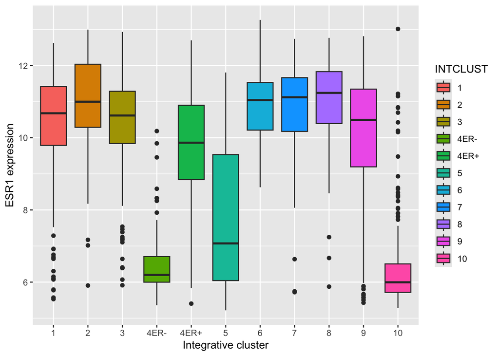

```r
# plot the ESR1 expression for each integrative cluster
plot <- metabric |> ggplot() +
  geom_boxplot(aes(x = INTCLUST, y = ESR1, fill = INTCLUST)) +
  labs(x = "Integrative cluster", y = "ESR1 expression")
plot
```

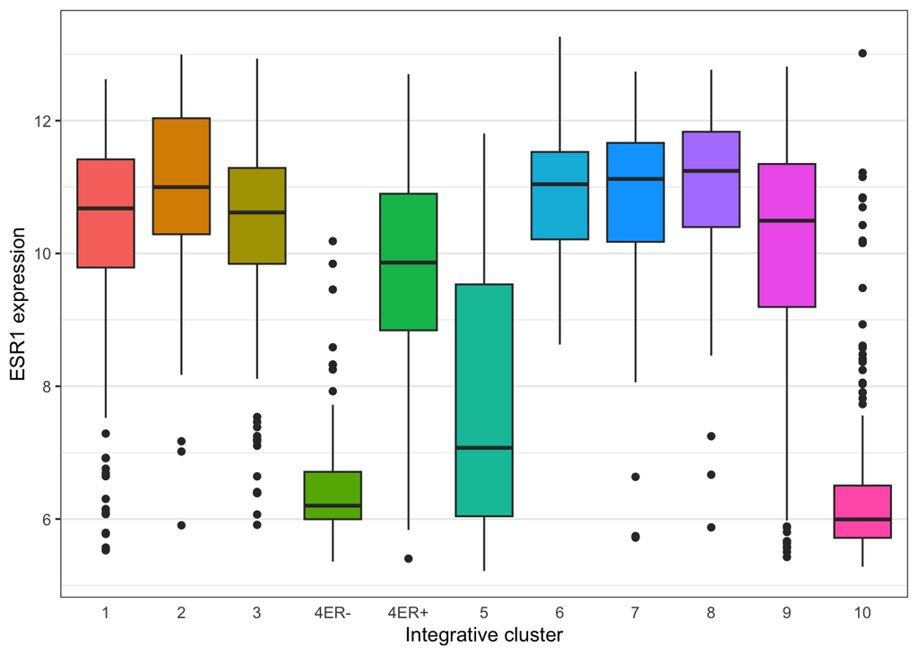

```r
plot +
  theme_bw() +
  theme(
    panel.grid.major.x = element_blank(),
    axis.ticks.x = element_blank(),
    legend.position = "none"
  )
```

### Task 2: Expression of estrogen receptor across 3-gene classification

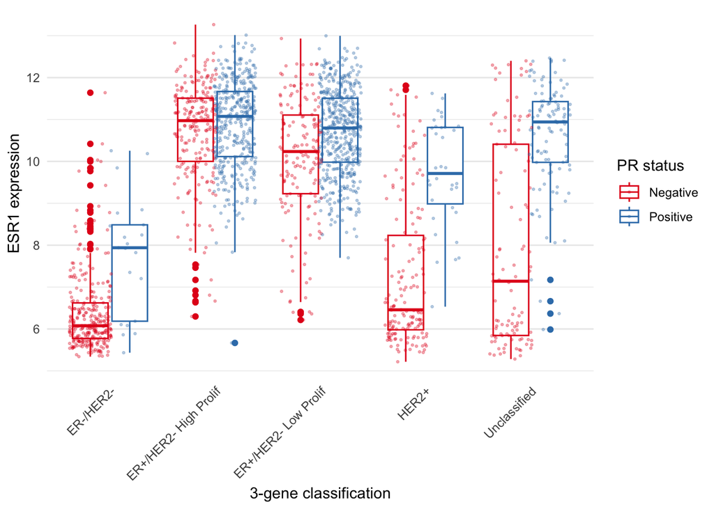

```r
metabric |>
  ggplot( aes(x = THREEGENE, y = ESR1, colour = PR_STATUS)) +
  geom_boxplot() +
  geom_point(position = position_jitterdodge(), size = 0.5, alpha = 0.3) +
  labs(x = "3-gene classification", y = "ESR1 expression", colour = "PR status") +
  scale_color_brewer(palette = "Set1") +
  theme_minimal() +
  theme(
    panel.grid.major.x = element_blank(),
    axis.text.x = element_text(angle = 45, hjust = 1, vjust = 1),
    axis.ticks.x = element_blank()
  )
```